# Chapter 4

Nate

12/17/2018

```r
knitr::opts_chunk$set(comment = NA, message=F, warning=F)
library(faraway)
library(tidyverse)
```

# 1.

```r
m <- lm(lpsa ~ ., data = prostate)
```

## a.

```r
new_data <- data.frame(
    lcavol = 1.44692,
    lweight = 3.62301,
    age = 65,
    lbph = 0.30010,
    svi = 0,
    lcp = -0.79851,
    gleason = 7,
    pgg45 = 15
)

predict(m, new_data, interval = "confidence")
```

```
       fit      lwr      upr
1 2.389053 2.172437 2.605669
```

## b.

```r
new_data$age <- 20

predict(m, new_data, interval = "confidence")
```

```
       fit      lwr      upr
1 3.272726 2.260444 4.285007
```

## c.

```r
summary(m)
```

```
Call:
lm(formula = lpsa ~ ., data = prostate)

Residuals:
    Min      1Q  Median      3Q     Max
-1.7331 -0.3713 -0.0170  0.4141  1.6381

Coefficients:
             Estimate Std. Error t value Pr(>|t|)
(Intercept)  0.669337   1.296387   0.516  0.60693
lcavol       0.587022   0.087920   6.677 2.11e-09 ***
lweight      0.454467   0.170012   2.673  0.00896 **
age         -0.019637   0.011173  -1.758  0.08229 .
lbph         0.107054   0.058449   1.832  0.07040 .
svi          0.766157   0.244309   3.136  0.00233 **
lcp         -0.105474   0.091013  -1.159  0.24964
gleason      0.045142   0.157465   0.287  0.77503
pgg45        0.004525   0.004421   1.024  0.30886
---
Signif. codes:  0 '***' 0.001 '**' 0.01 '*' 0.05 '.' 0.1 ' ' 1

Residual standard error: 0.7084 on 88 degrees of freedom
Multiple R-squared:  0.6548,    Adjusted R-squared:  0.6234
F-statistic: 20.86 on 8 and 88 DF,  p-value: < 2.2e-16
```

```r
m2 <- update(m, . ~ lcavol + lweight + svi)

predict(m2, new_data, interval = "confidence")
```

```
       fit      lwr      upr
1 2.372534 2.197274 2.547794
```

The CIs are narrower in the model with fewer predictors, because the original model had eight predictors to estimate, each with their own variance, and the revised model only contains a subset of three. Less predictors means less variance in the prediction esimate.

# 2.

```r
m <- lm(gamble ~ ., data = teengamb)
```

##a.

```r
avg_male <- filter(teengamb, sex == 0) %>%
    summarise_all(mean)

predict(m, avg_male, interval = "confidence")
```

```
     fit      lwr      upr
1 29.775 21.12132 38.42868
```

##b.

```r
max_male <- filter(teengamb, sex == 0) %>%
    summarise_all(max)

predict(m, max_male, interval = "confidence")
```

```
       fit      lwr      upr
1 71.30794 42.23237 100.3835
```

## c.

```r
sqrt_m <- update(m, sqrt(gamble) ~ .)

predict(sqrt_m, avg_male, interval = "confidence")^2
```

```
       fit      lwr      upr
1 19.27805 12.93025 26.88931
```

## d.

```r
hypothetical_female <- data.frame(
    sex = 1,
    status = 20,
    income = 1,
    verbal = 10
)

predict(sqrt_m, hypothetical_female, interval = 'confidence')^2
```

```
       fit      lwr        upr
1 4.353398 19.76636 0.07451699
```

The square root transformation causes odd results when squaring the prediction results, as the ‘upper’ bound is actually less than the ‘lower’ bound.

Aside from that the data of `hypothetical_female` is outside of the range of the model input data for both `income` and `verbal`. Cases when predictions are made on data points outside of the original data modeled, are an example of quantatative extrapolation and are dangerous because we must assume the same trends apply to these far different observations.

# 3.

```r
xtabs(water ~ ., data = snail) / 4 # four snails
```

```
    humid
temp    45    75   100
  20 72.50 81.50 97.00
  30 69.50 78.25 97.75
```

No this represents the average individual snail only at specific humidity and tempertaure values. To estimate values not in this table a linear model for the entire dataset is needed.

## b.

```r
m <- lm(water ~ ., data = snail)

new_condition <- data.frame(
    temp = 25,
    humid = 60
)

predict(m, new_condition)
```

```
       1
76.43681
```

## c.

```r
newest_condition <- data.frame(
    temp = 30,
    humid = 75
)

predict(m, newest_condition)
```

```
       1
82.62248
```

These predictions have equal merit, both sets of predictor values are within the modeled data’s range.

## d.

```r
intercept_data <- data.frame(
    humid = 0,
    temp = 0
    )

predict(m, intercept_data)
```

```
       1
52.61081
```

```r
intercept_data2 <- data.frame(
    humid = 100,
    temp = 256.4103
    )

predict(m, intercept_data2) # close
```

```
       1
52.95115
```

Since the linear model is, `y = intercept + (b1 * x1) + (b2 * x2)`, using 0 for both coefficients, `b`’s would return just the intercept.

Neither of these solutions is very usefuly because it s unlikely they would be encountered on Earth. When predicting from a linear model care should be exercised for new data far removed from that used to construct the model. Also always consider domain knowledge, like temperature required for snails to survive (256F is ridiculous), when drawing conclusions from any model predictions.

# 4.

```r
data(mdeaths) # error: data set ‘mdeaths’ not found
```

Because its a timeseries, `ts`, :(

```r
mdeaths
```

```
      Jan  Feb  Mar  Apr  May  Jun  Jul  Aug  Sep  Oct  Nov  Dec
1974 2134 1863 1877 1877 1492 1249 1280 1131 1209 1492 1621 1846
1975 2103 2137 2153 1833 1403 1288 1186 1133 1053 1347 1545 2066
1976 2020 2750 2283 1479 1189 1160 1113  970  999 1208 1467 2059
1977 2240 1634 1722 1801 1246 1162 1087 1013  959 1179 1229 1655
1978 2019 2284 1942 1423 1340 1187 1098 1004  970 1140 1110 1812
1979 2263 1820 1846 1531 1215 1075 1056  975  940 1081 1294 1341
```

```r
class(mdeaths)
```

```
[1] "ts"
```

## a.

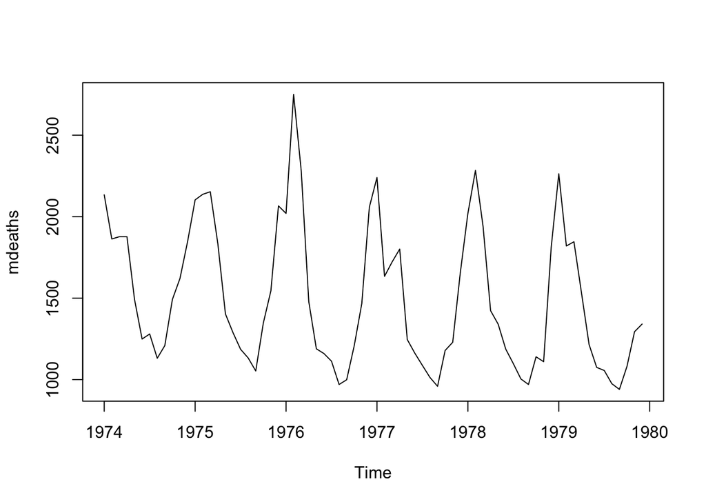

```r
plot(mdeaths)
```

Around the new year, January?

To get a better viz:

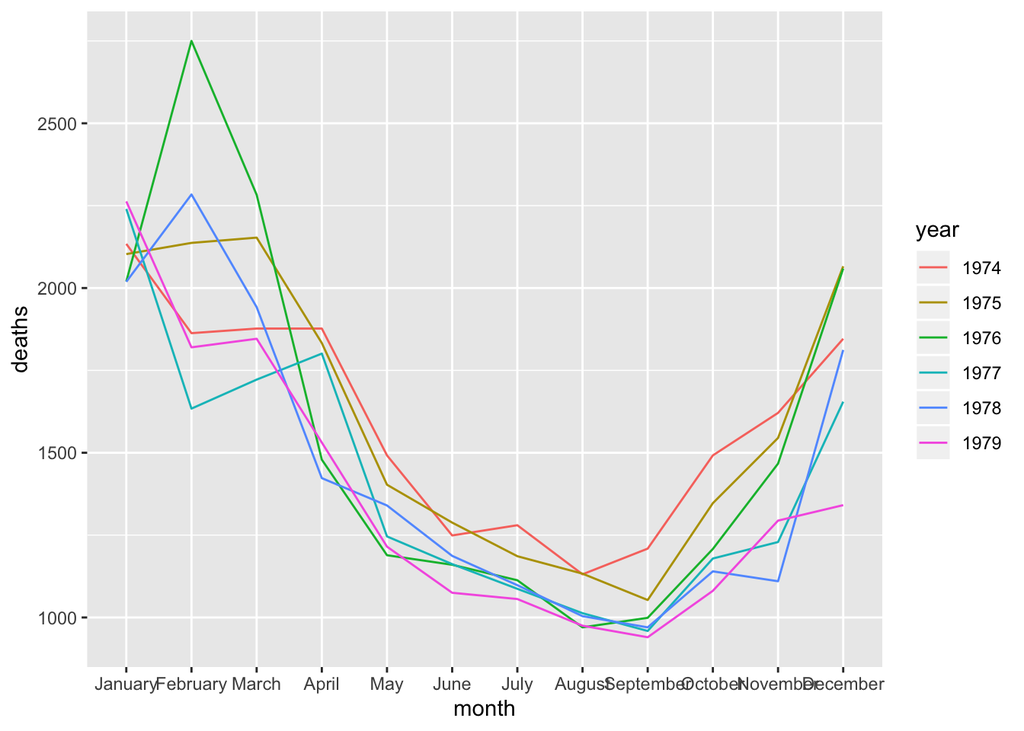

```r
mdeaths_df <- data.frame(deaths = as.numeric(mdeaths),
                         time = zoo::yearmon(time(mdeaths))) %>%
    mutate(month = factor(months(time), levels = month.name),
           year = format(time, "%Y"))

ggplot(mdeaths_df, aes(month, deaths, color = year, group = year)) +
    geom_line()
```

Yea January has the most adult deaths of any month.

## b.

```r
lag_df <- embed(mdeaths, 14) %>%
    as.data.frame() %>%
    setNames(c("y", paste0("lag_", 1:13)))

ar_m <- lm(y ~ lag_1 + lag_12 + lag_13, data = lag_df)

summary(ar_m)
```

```
Call:
lm(formula = y ~ lag_1 + lag_12 + lag_13, data = lag_df)

Residuals:
    Min      1Q  Median      3Q     Max
-762.71  -81.13  -21.12   61.76  724.06

Coefficients:
            Estimate Std. Error t value Pr(>|t|)
(Intercept)  58.1985   120.7358   0.482   0.6317
lag_1         0.2501     0.1327   1.885   0.0647 .
lag_12        0.5356     0.1179   4.542 3.09e-05 ***
lag_13        0.1512     0.1386   1.091   0.2801
---
Signif. codes:  0 '***' 0.001 '**' 0.01 '*' 0.05 '.' 0.1 ' ' 1

Residual standard error: 238.7 on 55 degrees of freedom
Multiple R-squared:   0.73, Adjusted R-squared:  0.7153
F-statistic: 49.56 on 3 and 55 DF,  p-value: 1.19e-15
```

No the `lag_1` (barely ~.065) and `lag_13` predictors are not significant at the common alpha level of .05.

## c.

The last value in this dataset in December 1979.

```r
last_obs <- lag_df[nrow(lag_df), ]
new_data <- data.frame(lag_1 = last_obs$y,
                       lag_12 = last_obs$lag_11,
                       lag_13 = last_obs$lag_12)

jan_1980 <- predict(ar_m, new_data, interval = "prediction")
jan_1980
```

```
       fit      lwr      upr
1 1879.599 1359.725 2399.474
```

```r
newer_data <- data.frame(lag_1 = jan_1980[1],
                         lag_12 = last_obs$lag_10,
                         lag_13 = last_obs$lag_11)

feb_1980 <- predict(ar_m, newer_data, interval = "prediction")
feb_1980
```

```
       fit     lwr      upr
1 1845.248 1345.87 2344.625
```

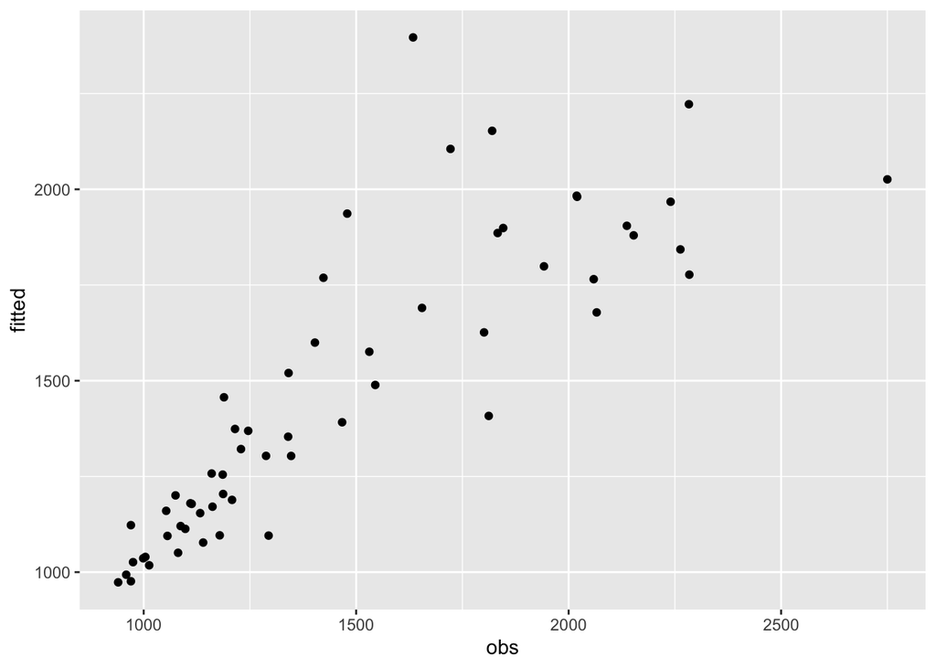

```r
fit_results <- data.frame(obs = lag_df$y,
                          fitted = ar_m$fitted.values,
                          month = rep_len(month.abb[c(2:12, 1)], nrow(lag_df))) # predictions start in February

ggplot(fit_results, aes(obs, fitted)) +
    geom_point()
```

Accurary should be better for months with tighter historical spreads, like the summer months.

Using absolute percentage error for a unit-less accuracy metric to avoid any scale-dependent bias.

```r
fit_results %>%
    mutate(ape = abs(100 * (obs - fitted) / obs)) %>%
    group_by(month) %>%
    summarise(avg_ape = mean(ape)) %>%
    arrange(avg_ape)
```

```
# A tibble: 12 x 2
   month avg_ape
   <fct>   <dbl>
 1 Jul      3.95
 2 Oct      4.04
 3 Sep      4.33
 4 Jun      4.70
 5 Aug      5.38
 6 Nov      7.59
 7 Jan      8.62
 8 Mar      9.57
 9 May     12.1
10 Apr     14.1
11 Dec     14.2
12 Feb     24.9
```

# 5

```r
# drop the 14 columns used
fat <-  select(fat, age, weight, height, neck, chest,
                abdom, hip, thigh, knee, ankle,
                biceps, forearm, wrist, brozek)

library(skimr)
skim(fat)
```

Data summary

| Name | fat |
| --- | --- |
| Number of rows | 252 |
| Number of columns | 14 |
| _______________________ |  |
| Column type frequency: |  |
| numeric | 14 |
| ________________________ |  |
| Group variables | None |

**Variable type: numeric**

| skim_variable | n_missing | complete_rate | mean | sd | p0 | p25 | p50 | p75 | p100 | hist |
| --- | --- | --- | --- | --- | --- | --- | --- | --- | --- | --- |
| age | 0 | 1 | 44.88 | 12.60 | 22.0 | 35.75 | 43.00 | 54.00 | 81.00 | ▅▇▇▃▁ |
| weight | 0 | 1 | 178.92 | 29.39 | 118.5 | 159.00 | 176.50 | 197.00 | 363.15 | ▆▇▂▁▁ |
| height | 0 | 1 | 70.15 | 3.66 | 29.5 | 68.25 | 70.00 | 72.25 | 77.75 | ▁▁▁▂▇ |
| neck | 0 | 1 | 37.99 | 2.43 | 31.1 | 36.40 | 38.00 | 39.42 | 51.20 | ▂▇▃▁▁ |
| chest | 0 | 1 | 100.82 | 8.43 | 79.3 | 94.35 | 99.65 | 105.38 | 136.20 | ▂▇▅▁▁ |
| abdom | 0 | 1 | 92.56 | 10.78 | 69.4 | 84.57 | 90.95 | 99.33 | 148.10 | ▃▇▂▁▁ |
| hip | 0 | 1 | 99.90 | 7.16 | 85.0 | 95.50 | 99.30 | 103.53 | 147.70 | ▆▇▁▁▁ |
| thigh | 0 | 1 | 59.41 | 5.25 | 47.2 | 56.00 | 59.00 | 62.35 | 87.30 | ▃▇▃▁▁ |
| knee | 0 | 1 | 38.59 | 2.41 | 33.0 | 36.98 | 38.50 | 39.92 | 49.10 | ▃▇▅▁▁ |
| ankle | 0 | 1 | 23.10 | 1.69 | 19.1 | 22.00 | 22.80 | 24.00 | 33.90 | ▃▇▁▁▁ |
| biceps | 0 | 1 | 32.27 | 3.02 | 24.8 | 30.20 | 32.05 | 34.32 | 45.00 | ▂▇▆▁▁ |
| forearm | 0 | 1 | 28.66 | 2.02 | 21.0 | 27.30 | 28.70 | 30.00 | 34.90 | ▁▂▇▆▁ |
| wrist | 0 | 1 | 18.23 | 0.93 | 15.8 | 17.60 | 18.30 | 18.80 | 21.40 | ▂▆▇▂▁ |
| brozek | 0 | 1 | 18.94 | 7.75 | 0.0 | 12.80 | 19.00 | 24.60 | 45.10 | ▂▇▇▃▁ |

```r
m <- lm(brozek ~ age + weight + height + abdom, fat)
```

## a

```r
full_m <- lm(brozek ~ ., fat)
anova(m, full_m)
```

```
Analysis of Variance Table

Model 1: brozek ~ age + weight + height + abdom
Model 2: brozek ~ age + weight + height + neck + chest + abdom + hip +
    thigh + knee + ankle + biceps + forearm + wrist
  Res.Df    RSS Df Sum of Sq      F   Pr(>F)
1    247 4205.0
2    238 3785.1  9     419.9 2.9336 0.002558 **
---
Signif. codes:  0 '***' 0.001 '**' 0.01 '*' 0.05 '.' 0.1 ' ' 1
```

No, the smaller model is significantly worse.

## b.

```r
median_dat <- summarise_all(fat, median)

predict(m, newdata = median_dat, interval = "prediction")
```

```
       fit      lwr      upr
1 17.84028 9.696631 25.98392
```

```r
predict(full_m, newdata = median_dat, interval = "prediction")
```

```
       fit     lwr      upr
1 17.49322 9.61783 25.36861
```

The ranges are almost identical so we don’t lose a lot of predictive power with the smaller version.

## c.

Let’s just look at all of the cases…

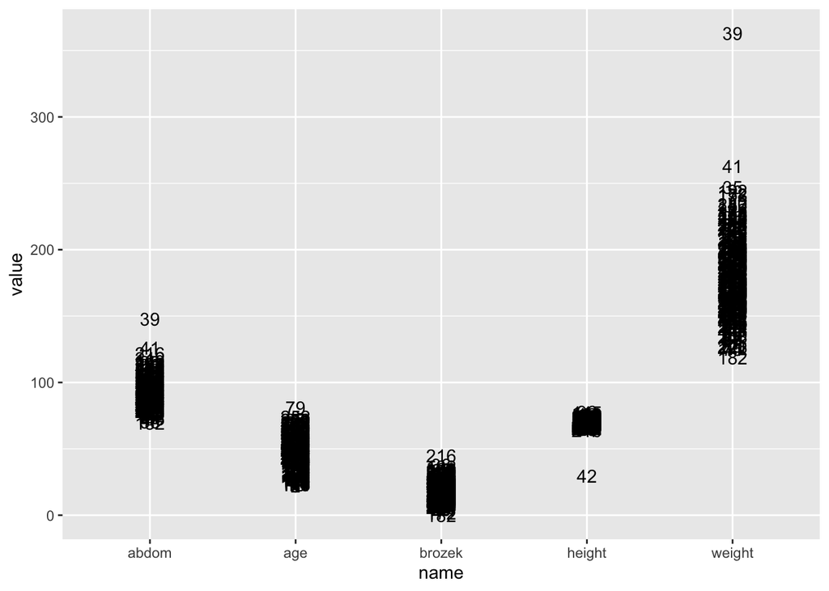

```r
m$model %>%
    as.data.frame() %>%
    add_rownames("case_id") %>%
    pivot_longer(-case_id) %>%
    ggplot(aes(name, value, label = case_id)) +
    geom_text()
```

Let’s consider 39 and 42 to be the outliers.

## d.

```r
update(m, data = fat[c(-39, -42), ]) %>%
    predict(median_dat, interval = "prediction")
```

```
       fit      lwr      upr
1 17.91062 9.894975 25.92627
```

Dropping the outliers doesn’t change things a whole lot.